# Lab6

jche827

18/09/2021

# The Data Set

The data source for this lab is from UCI Machine Learning Repository. We are going to use the Automobile data set. # Tasks

# Import

## 1. Produce a tidier file automobile.csv

```r
automobileoriginal <- read.csv("automobile-original.csv")
automobilesubset <- read.csv("automobile-subset.csv")

head(automobileoriginal)
```

```
##   symboling normalized.losses        make fuel.type aspiration num.of.doors
## 1         3                 ? alfa-romero       gas        std          two
## 2         3                 ? alfa-romero       gas        std          two
## 3         1                 ? alfa-romero       gas        std          two
## 4         2               164        audi       gas        std         four
## 5         2               164        audi       gas        std         four
## 6         2                 ?        audi       gas        std          two
##    body.style drive.wheels engine.location wheel.base length width height
## 1 convertible          rwd           front       88.6  168.8  64.1   48.8
## 2 convertible          rwd           front       88.6  168.8  64.1   48.8
## 3   hatchback          rwd           front       94.5  171.2  65.5   52.4
## 4       sedan          fwd           front       99.8  176.6  66.2   54.3
## 5       sedan          4wd           front       99.4  176.6  66.4   54.3
## 6       sedan          fwd           front       99.8  177.3  66.3   53.1
##   curb.weight engine.type num.of.cylinders engine.size fuel.system bore stroke
## 1        2548        dohc             four         130        mpfi 3.47   2.68
## 2        2548        dohc             four         130        mpfi 3.47   2.68
## 3        2823        ohcv              six         152        mpfi 2.68   3.47
## 4        2337         ohc             four         109        mpfi 3.19   3.40
## 5        2824         ohc             five         136        mpfi 3.19   3.40
## 6        2507         ohc             five         136        mpfi 3.19   3.40
##   compression.ratio horsepower peak.rpm city.mpg highway.mpg price
## 1               9.0        111     5000       21          27 13495
## 2               9.0        111     5000       21          27 16500
## 3               9.0        154     5000       19          26 16500
## 4              10.0        102     5500       24          30 13950
## 5               8.0        115     5500       18          22 17450
## 6               8.5        110     5500       19          25 15250
```

```r
head(automobilesubset)
```

```
##   symboling normalized.losses make fuel.type aspiration num.of.doors body.style
## 1         2               164 audi       gas        std         four      sedan
## 2         2               164 audi       gas        std         four      sedan
## 3         1               158 audi       gas        std         four      sedan
## 4         1               158 audi       gas      turbo         four      sedan
## 5         2               192  bmw       gas        std          two      sedan
## 6         0               192  bmw       gas        std         four      sedan
##   drive.wheels wheel.base length width height curb.weight engine.type
## 1          fwd       99.8  176.6  66.2   54.3        2337         ohc
## 2          4wd       99.4  176.6  66.4   54.3        2824         ohc
## 3          fwd      105.8  192.7  71.4   55.7        2844         ohc
## 4          fwd      105.8  192.7  71.4   55.9        3086         ohc
## 5          rwd      101.2  176.8  64.8   54.3        2395         ohc
## 6          rwd      101.2  176.8  64.8   54.3        2395         ohc
##   num.of.cylinders engine.size fuel.system bore stroke compression.ratio
## 1             four         109        mpfi 3.19    3.4              10.0
## 2             five         136        mpfi 3.19    3.4               8.0
## 3             five         136        mpfi 3.19    3.4               8.5
## 4             five         131        mpfi 3.13    3.4               8.3
## 5             four         108        mpfi 3.50    2.8               8.8
## 6             four         108        mpfi 3.50    2.8               8.8
##   horsepower peak.rpm city.mpg highway.mpg price
## 1        102     5500       24          30 13950
## 2        115     5500       18          22 17450
## 3        110     5500       19          25 17710
## 4        140     5500       17          20 23875
## 5        101     5800       23          29 16430
## 6        101     5800       23          29 16925
```

### Write R code that can reproduce the second data set from the first one

```r
automobile <- automobileoriginal[,-c(9)]
automobile[automobile=='?'] <- NA
automobile <- na.omit(automobile)
write.csv(automobile,"automobile.csv", row.names = FALSE)
```

### Ensure that the values are identical to those from automobile-subset.csv

```r
automobile <- read.csv("automobile.csv")
automobilesubset <- read.csv("automobile-subset.csv")
all(automobile == automobilesubset)
```

```
## [1] TRUE
```

# Explore

```r
dim(automobile)
```

```
## [1] 159  25
```

## 2. Write R code to answer the following questions:

### What is the mean price (price) of all vehicles?

```r
mean(automobile$price)
```

```
## [1] 11445.73
```

### How many vehicles have 4 doors (num.of.doors)?

```r
occurences<-table(unlist(automobile$num.of.doors))
occurences
```

```
##
## four  two
##   95   64
```

#### There are 95 four doored cars

### What are the different engine types (engine.type) among the observations?

```r
occurences2 <- table(unlist(automobile$engine.type))
occurences2
```

```
##
## dohc    l  ohc ohcf ohcv
##    8    8  123   12    8
```

### How many vehicles have a price (price) higher than $20000?

```r
occurences3 <- table(unlist(automobile$price > 20000))
occurences3
```

```
##
## FALSE  TRUE
##   146    13
```

#### 13 cars are priced over $20k

### What is the mean price (price) for “4wd” (drive.wheels)

```r
mean(automobile[automobile$drive.wheels == "4wd", 25])
```

```
## [1] 10241
```

## 3. Produce pairwise scatterplots between variables normalized.losses, wheel.base, peak.rpm and price.

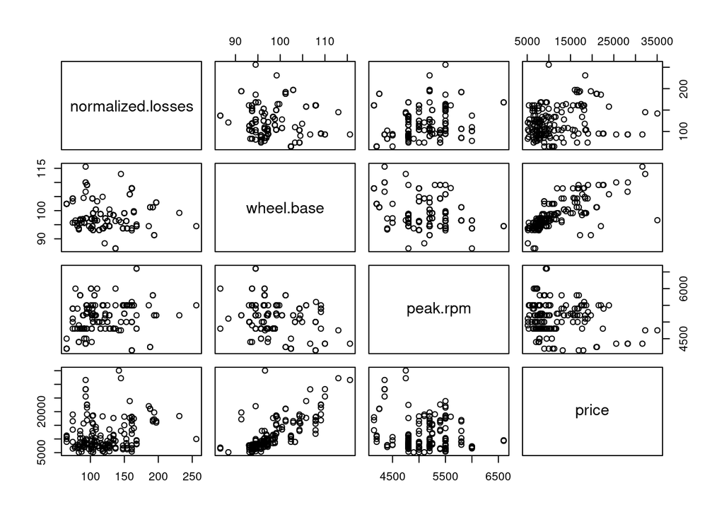

```r
pairs(automobile[, c('normalized.losses', 'wheel.base', 'peak.rpm', 'price')])
```

# Linear regression

## 4. Produce the full linear regression model with all variables included

```r
r = lm(price ~ ., data=automobile)
summary(r)
```

```
##
## Call:
## lm(formula = price ~ ., data = automobile)
##
## Residuals:
##     Min      1Q  Median      3Q     Max
## -2949.8  -587.9     0.0   650.3  2259.2
##
## Coefficients: (3 not defined because of singularities)
##                         Estimate Std. Error t value Pr(>|t|)
## (Intercept)            2.309e+04  1.560e+04   1.480 0.141731
## symboling             -5.068e+00  2.163e+02  -0.023 0.981351
## normalized.losses      5.577e+00  6.252e+00   0.892 0.374295
## makebmw                3.596e+02  1.791e+03   0.201 0.841251
## makechevrolet         -4.745e+03  1.856e+03  -2.556 0.011985 *
## makedodge             -6.209e+03  1.613e+03  -3.851 0.000201 ***
## makehonda             -1.583e+03  1.739e+03  -0.910 0.364854
## makejaguar             2.431e+03  2.918e+03   0.833 0.406615
## makemazda             -4.063e+03  1.568e+03  -2.591 0.010906 *
## makemercedes-benz      2.548e+03  1.608e+03   1.584 0.116050
## makemitsubishi        -6.328e+03  1.578e+03  -4.010 0.000113 ***
## makenissan            -3.690e+03  1.470e+03  -2.510 0.013557 *
## makepeugot            -5.143e+03  4.732e+03  -1.087 0.279561
## makeplymouth          -6.025e+03  1.618e+03  -3.723 0.000316 ***
## makeporsche            4.830e+03  2.091e+03   2.310 0.022810 *
## makesaab              -4.040e+02  1.552e+03  -0.260 0.795107
## makesubaru            -7.317e+03  2.301e+03  -3.180 0.001927 **
## maketoyota            -5.869e+03  1.594e+03  -3.682 0.000364 ***
## makevolkswagen        -4.297e+03  1.355e+03  -3.170 0.001986 **
## makevolvo             -2.871e+03  1.838e+03  -1.563 0.121105
## fuel.typegas          -1.065e+04  5.139e+03  -2.072 0.040708 *
## aspirationturbo        2.171e+03  5.956e+02   3.646 0.000413 ***
## num.of.doorstwo       -8.381e+02  3.795e+02  -2.208 0.029366 *
## body.stylehardtop     -5.627e+03  1.375e+03  -4.091 8.33e-05 ***
## body.stylehatchback   -5.736e+03  1.343e+03  -4.271 4.23e-05 ***
## body.stylesedan       -5.702e+03  1.398e+03  -4.080 8.71e-05 ***
## body.stylewagon       -5.647e+03  1.414e+03  -3.995 0.000119 ***
## drive.wheelsfwd       -2.936e+01  6.501e+02  -0.045 0.964064
## drive.wheelsrwd        1.977e+03  9.553e+02   2.070 0.040895 *
## wheel.base             3.184e+02  8.310e+01   3.832 0.000215 ***
```

[output cut: 16 more lines]

```
## fuel.systemmpfi        2.602e+03  1.081e+03   2.407 0.017808 *
## fuel.systemspdi        1.081e+03  1.292e+03   0.837 0.404621
## bore                  -8.817e+02  1.427e+03  -0.618 0.538041
## stroke                -5.677e+02  9.524e+02  -0.596 0.552409
## compression.ratio     -7.000e+02  3.844e+02  -1.821 0.071380 .
## horsepower            -2.019e+01  1.911e+01  -1.057 0.292973
## peak.rpm              -5.377e-01  5.658e-01  -0.950 0.344070
## city.mpg              -1.564e+02  1.030e+02  -1.518 0.131872
## highway.mpg            1.284e+02  8.912e+01   1.441 0.152517
## ---
## Signif. codes:  0 '***' 0.001 '**' 0.01 '*' 0.05 '.' 0.1 ' ' 1
##
## Residual standard error: 1165 on 107 degrees of freedom
## Multiple R-squared:  0.9734, Adjusted R-squared:  0.9607
## F-statistic: 76.78 on 51 and 107 DF,  p-value: < 2.2e-16
```

### Comment on the outcome

There are many seem to cause the linear regression to fail, i.e., some coefficients may become NA. These include: engine.typeohcf, num.of.cylindersthree and fuel.systemidi. the adjusted R squared value is 96.07%, which is a high result although many variables are not extremely significant (p-value > 5%).

## 5. Remove any variable(s) that seem to cause the linear regression to fail. Repeat this until you can produce a meaningful “full” linear regression model

```r
# removing num.of.cylinders, as some values cause the linear regression to fail
r2 = lm(price ~ . - num.of.cylinders, data=automobile)
summary(r2)
```

```
##
## Call:
## lm(formula = price ~ . - num.of.cylinders, data = automobile)
##
## Residuals:
##     Min      1Q  Median      3Q     Max
## -3092.7  -628.6     0.0   683.6  2609.8
##
## Coefficients: (2 not defined because of singularities)
##                       Estimate Std. Error t value Pr(>|t|)
## (Intercept)          2.567e+04  1.548e+04   1.659 0.100016
## symboling            2.896e+01  2.150e+02   0.135 0.893091
## normalized.losses    4.794e+00  6.195e+00   0.774 0.440688
## makebmw              1.090e+03  1.388e+03   0.786 0.433769
## makechevrolet       -4.901e+03  1.545e+03  -3.172 0.001960 **
## makedodge           -6.491e+03  1.216e+03  -5.336 5.14e-07 ***
## makehonda           -1.914e+03  1.335e+03  -1.434 0.154498
## makejaguar           1.089e+03  2.280e+03   0.478 0.633944
## makemazda           -4.215e+03  1.073e+03  -3.929 0.000149 ***
## makemercedes-benz    2.584e+03  1.511e+03   1.710 0.090035 .
## makemitsubishi      -6.695e+03  1.108e+03  -6.042 2.12e-08 ***
## makenissan          -3.865e+03  1.066e+03  -3.624 0.000440 ***
## makepeugot          -1.007e+04  2.010e+03  -5.012 2.07e-06 ***
## makeplymouth        -6.336e+03  1.224e+03  -5.176 1.03e-06 ***
## makeporsche          5.068e+03  1.744e+03   2.905 0.004434 **
## makesaab            -4.146e+02  1.218e+03  -0.340 0.734147
## makesubaru          -7.656e+03  1.942e+03  -3.942 0.000142 ***
## maketoyota          -6.008e+03  1.194e+03  -5.031 1.91e-06 ***
## makevolkswagen      -4.395e+03  9.447e+02  -4.652 9.22e-06 ***
## makevolvo           -2.408e+03  1.372e+03  -1.755 0.082124 .
## fuel.typegas        -1.066e+04  4.601e+03  -2.316 0.022432 *
## aspirationturbo      2.159e+03  5.949e+02   3.630 0.000432 ***
## num.of.doorstwo     -8.892e+02  3.779e+02  -2.353 0.020403 *
## body.stylehardtop   -6.365e+03  1.133e+03  -5.617 1.48e-07 ***
## body.stylehatchback -6.450e+03  1.062e+03  -6.071 1.85e-08 ***
## body.stylesedan     -6.320e+03  1.138e+03  -5.554 1.96e-07 ***
## body.stylewagon     -6.230e+03  1.174e+03  -5.306 5.85e-07 ***
## drive.wheelsfwd     -1.639e+00  6.490e+02  -0.003 0.997990
## drive.wheelsrwd      1.944e+03  9.476e+02   2.051 0.042617 *
## wheel.base           3.150e+02  7.875e+01   4.001 0.000115 ***
```

[output cut: 12 more lines]

```
## fuel.systemmpfi      2.504e+03  1.073e+03   2.332 0.021497 *
## fuel.systemspdi      1.155e+03  1.287e+03   0.897 0.371649
## bore                -2.272e+03  9.417e+02  -2.412 0.017497 *
## stroke              -4.385e+02  9.221e+02  -0.476 0.635317
## compression.ratio   -7.207e+02  3.408e+02  -2.115 0.036690 *
## horsepower          -2.476e+01  1.811e+01  -1.367 0.174370
## peak.rpm            -6.063e-01  5.464e-01  -1.109 0.269648
## city.mpg            -1.462e+02  1.018e+02  -1.437 0.153580
## highway.mpg          1.075e+02  8.773e+01   1.225 0.223248
## ---
## Signif. codes:  0 '***' 0.001 '**' 0.01 '*' 0.05 '.' 0.1 ' ' 1
##
## Residual standard error: 1164 on 110 degrees of freedom
## Multiple R-squared:  0.9727, Adjusted R-squared:  0.9608
## F-statistic: 81.61 on 48 and 110 DF,  p-value: < 2.2e-16
```

The adjusted R squared value improves (to 96.08%)

```r
# removing engine.type, as some cause they lm to fail.
r3 = lm(price ~ . - num.of.cylinders -engine.type, data=automobile)
summary(r3)
```

```
##
## Call:
## lm(formula = price ~ . - num.of.cylinders - engine.type, data = automobile)
##
## Residuals:
##     Min      1Q  Median      3Q     Max
## -3020.2  -669.3   -39.8   686.3  2661.8
##
## Coefficients: (1 not defined because of singularities)
##                       Estimate Std. Error t value Pr(>|t|)
## (Intercept)          1.107e+04  1.510e+04   0.733 0.464973
## symboling            7.799e+01  2.204e+02   0.354 0.724165
## normalized.losses    8.700e+00  6.326e+00   1.375 0.171759
## makebmw              1.435e+03  1.427e+03   1.005 0.316818
## makechevrolet       -3.794e+03  1.526e+03  -2.486 0.014385 *
## makedodge           -5.898e+03  1.240e+03  -4.755 5.91e-06 ***
## makehonda           -1.698e+03  1.379e+03  -1.231 0.220922
## makejaguar           3.157e+03  2.224e+03   1.420 0.158496
## makemazda           -3.273e+03  1.064e+03  -3.076 0.002635 **
## makemercedes-benz    3.748e+03  1.520e+03   2.466 0.015182 *
## makemitsubishi      -6.065e+03  1.129e+03  -5.372 4.22e-07 ***
## makenissan          -3.359e+03  1.062e+03  -3.161 0.002017 **
## makepeugot          -6.350e+03  1.335e+03  -4.758 5.83e-06 ***
## makeplymouth        -5.733e+03  1.246e+03  -4.600 1.11e-05 ***
## makeporsche          4.667e+03  1.747e+03   2.671 0.008684 **
## makesaab             7.382e+01  1.229e+03   0.060 0.952215
## makesubaru          -3.965e+03  1.514e+03  -2.619 0.010028 *
## maketoyota          -4.707e+03  1.151e+03  -4.090 8.12e-05 ***
## makevolkswagen      -3.938e+03  9.340e+02  -4.217 5.02e-05 ***
## makevolvo           -1.800e+03  1.416e+03  -1.271 0.206441
## fuel.typegas        -7.231e+03  4.620e+03  -1.565 0.120363
## aspirationturbo      2.005e+03  6.171e+02   3.249 0.001528 **
## num.of.doorstwo     -8.765e+02  3.912e+02  -2.241 0.027002 *
## body.stylehardtop   -6.615e+03  1.175e+03  -5.628 1.34e-07 ***
## body.stylehatchback -6.188e+03  1.103e+03  -5.611 1.45e-07 ***
## body.stylesedan     -6.017e+03  1.180e+03  -5.099 1.39e-06 ***
## body.stylewagon     -6.059e+03  1.219e+03  -4.970 2.41e-06 ***
## drive.wheelsfwd     -7.645e+01  6.704e+02  -0.114 0.909404
## drive.wheelsrwd      1.392e+03  9.514e+02   1.463 0.146172
## wheel.base           3.108e+02  7.839e+01   3.965 0.000129 ***
```

[output cut: 8 more lines]

```
## fuel.systemmpfi      2.379e+03  1.107e+03   2.150 0.033719 *
## fuel.systemspdi      1.052e+03  1.335e+03   0.788 0.432260
## bore                -2.494e+03  9.628e+02  -2.590 0.010856 *
## stroke              -5.323e+02  8.418e+02  -0.632 0.528450
## compression.ratio   -4.276e+02  3.390e+02  -1.261 0.209785
## horsepower           4.537e+00  1.619e+01   0.280 0.779819
## peak.rpm             1.505e-02  5.033e-01   0.030 0.976197
## city.mpg            -8.705e+01  1.040e+02  -0.837 0.404498
## highway.mpg          8.493e+01  9.061e+01   0.937 0.350594
## ---
## Signif. codes:  0 '***' 0.001 '**' 0.01 '*' 0.05 '.' 0.1 ' ' 1
##
## Residual standard error: 1212 on 113 degrees of freedom
## Multiple R-squared:  0.9696, Adjusted R-squared:  0.9575
## F-statistic: 80.13 on 45 and 113 DF,  p-value: < 2.2e-16
```

The adjusted R square value decerases to 95.75%. I believe this is due to removal of overfitted values when the NA values we’re removed. The values we have removed were mostly p>5% anyway, so this should be a more accurate regression model.

```r
# repeat previous step, removing fuel.system
r4 = lm(price ~ . - num.of.cylinders -engine.type -fuel.system, data=automobile)
summary(r4)
```

```
##
## Call:
## lm(formula = price ~ . - num.of.cylinders - engine.type - fuel.system,
##     data = automobile)
##
## Residuals:
##     Min      1Q  Median      3Q     Max
## -2909.8  -689.8     0.0   751.5  3022.7
##
## Coefficients:
##                       Estimate Std. Error t value Pr(>|t|)
## (Intercept)          7155.6764 14806.9394   0.483 0.629811
## symboling             173.7842   209.0850   0.831 0.407573
## normalized.losses       7.8808     6.3050   1.250 0.213818
## makebmw              1796.0533  1412.4324   1.272 0.206036
## makechevrolet       -3428.6299  1463.3476  -2.343 0.020818 *
## makedodge           -5458.7243  1147.3270  -4.758 5.64e-06 ***
## makehonda           -3173.5356  1136.8367  -2.792 0.006128 **
## makejaguar           3691.5788  2152.5433   1.715 0.088995 .
## makemazda           -3125.7748  1024.2237  -3.052 0.002815 **
## makemercedes-benz    4074.2419  1453.3526   2.803 0.005922 **
## makemitsubishi      -6282.4391  1054.8501  -5.956 2.78e-08 ***
## makenissan          -3179.8322  1025.1301  -3.102 0.002411 **
## makepeugot          -6028.8679  1332.0667  -4.526 1.45e-05 ***
## makeplymouth        -5534.2343  1182.3459  -4.681 7.75e-06 ***
## makeporsche          4456.2364  1752.4187   2.543 0.012299 *
## makesaab             -217.9398  1233.6731  -0.177 0.860081
## makesubaru          -4149.8831  1505.4175  -2.757 0.006777 **
## maketoyota          -4535.8323  1127.8013  -4.022 0.000103 ***
## makevolkswagen      -3849.1614   936.1258  -4.112 7.32e-05 ***
## makevolvo           -1520.0825  1383.1896  -1.099 0.274038
## fuel.typegas        -3388.2026  4292.7306  -0.789 0.431540
## aspirationturbo      1579.3616   596.2638   2.649 0.009194 **
## num.of.doorstwo      -792.7024   389.5484  -2.035 0.044118 *
## body.stylehardtop   -6541.2889  1182.2878  -5.533 1.95e-07 ***
## body.stylehatchback -6077.5946  1094.0194  -5.555 1.76e-07 ***
## body.stylesedan     -5757.8523  1168.2868  -4.928 2.76e-06 ***
## body.stylewagon     -5854.7705  1217.1038  -4.810 4.53e-06 ***
## drive.wheelsfwd      -137.4952   672.7180  -0.204 0.838406
## drive.wheelsrwd      1100.7900   954.2638   1.154 0.251036
## wheel.base            306.6190    78.0295   3.930 0.000144 ***
## length                -82.3267    36.3865  -2.263 0.025508 *
## width                 219.3607   189.6970   1.156 0.249884
## height               -302.2128   116.8286  -2.587 0.010912 *
## curb.weight             5.0845     1.2858   3.954 0.000132 ***
## engine.size             6.3416    17.2988   0.367 0.714586
## bore                -2107.5221   950.2712  -2.218 0.028499 *
## stroke               -612.5968   844.5955  -0.725 0.469708
## compression.ratio    -289.1482   323.3432  -0.894 0.373027
## horsepower             12.7864    15.4473   0.828 0.409502
## peak.rpm               -0.2641     0.4892  -0.540 0.590352
## city.mpg              -70.5852   102.0362  -0.692 0.490455
## highway.mpg            56.7894    89.3999   0.635 0.526519
## ---
## Signif. codes:  0 '***' 0.001 '**' 0.01 '*' 0.05 '.' 0.1 ' ' 1
##
## Residual standard error: 1227 on 117 degrees of freedom
## Multiple R-squared:  0.9677, Adjusted R-squared:  0.9564
## F-statistic: 85.61 on 41 and 117 DF,  p-value: < 2.2e-16
```

```r
# removing variables with low significance
r5 = lm(price ~ . - num.of.cylinders -engine.type -fuel.system -symboling -normalized.losses -fuel.type -drive.wheels -stroke -compression.ratio -horsepower -peak.rpm -city.mpg -highway.mpg -num.of.doors -width -engine.size -bore, data=automobile)
summary(r5)
```

```
##
## Call:
## lm(formula = price ~ . - num.of.cylinders - engine.type - fuel.system -
##     symboling - normalized.losses - fuel.type - drive.wheels -
##     stroke - compression.ratio - horsepower - peak.rpm - city.mpg -
##     highway.mpg - num.of.doors - width - engine.size - bore,
##     data = automobile)
##
## Residuals:
##     Min      1Q  Median      3Q     Max
## -3568.1  -718.5     0.0   761.2  3388.4
##
## Coefficients:
##                       Estimate Std. Error t value Pr(>|t|)
## (Intercept)         17545.8046  5561.1838   3.155  0.00199 **
## makebmw              1891.7768   940.4097   2.012  0.04629 *
## makechevrolet       -5174.3232  1129.4968  -4.581 1.06e-05 ***
## makedodge           -7016.5316   919.0685  -7.634 4.06e-12 ***
## makehonda           -4942.3095   842.0192  -5.870 3.34e-08 ***
## makejaguar           1660.8011  1649.9623   1.007  0.31598
## makemazda           -4079.8350   804.9505  -5.068 1.33e-06 ***
## makemercedes-benz    2427.1680  1020.7611   2.378  0.01885 *
## makemitsubishi      -7740.9957   871.5348  -8.882 4.16e-15 ***
## makenissan          -4428.8483   772.7157  -5.732 6.44e-08 ***
## makepeugot          -6344.5641   882.4084  -7.190 4.32e-11 ***
## makeplymouth        -6971.8439   935.7555  -7.450 1.09e-11 ***
## makeporsche          3020.1356  1537.3998   1.964  0.05158 .
## makesaab             -895.9382   943.6575  -0.949  0.34414
## makesubaru          -6182.5398   819.1698  -7.547 6.47e-12 ***
## maketoyota          -5851.6565   734.6484  -7.965 6.74e-13 ***
## makevolkswagen      -4827.2739   832.0878  -5.801 4.63e-08 ***
## makevolvo           -2631.9593   787.7118  -3.341  0.00108 **
## aspirationturbo      1528.8227   344.3151   4.440 1.88e-05 ***
## body.stylehardtop   -6464.2233  1191.0415  -5.427 2.65e-07 ***
## body.stylehatchback -5740.1541  1091.2591  -5.260 5.66e-07 ***
## body.stylesedan     -5259.8857  1117.9039  -4.705 6.32e-06 ***
## body.stylewagon     -5260.1700  1180.6115  -4.455 1.77e-05 ***
## wheel.base            297.8070    68.7111   4.334 2.88e-05 ***
## length                -92.4143    35.4394  -2.608  0.01017 *
## height               -527.9562    93.6824  -5.636 1.01e-07 ***
## curb.weight             7.6176     0.6454  11.804  < 2e-16 ***
## ---
## Signif. codes:  0 '***' 0.001 '**' 0.01 '*' 0.05 '.' 0.1 ' ' 1
##
## Residual standard error: 1299 on 132 degrees of freedom
## Multiple R-squared:  0.9592, Adjusted R-squared:  0.9511
## F-statistic: 119.3 on 26 and 132 DF,  p-value: < 2.2e-16
```

### How many variables are deemed to be significant by the t-tests (with a p-value less than 0.05)?

24 variables are significant (out of 27) with a p vvalue <5%. If you consider the makeporsche variable to be significant as it has a p value of 0.05158, which is very close to significance, then 25 variables are significant.

## 6. Apply your “full” linear regression model to the data and compute the resulting mean squared error (MSE)

```r
mse = function(y1, y2) mean( (y1 - y2)^2 )
sqerr = mse(predict(r5, automobile), automobile$price)
sqerr
```

```
## [1] 1401914
```

```r
# square root of mean squared error:
sqrt(sqerr)
```

```
## [1] 1184.024
```

# Subset selection

```r
# load libraries
library(leaps)
library(glmnet)
```

```r
r.bwd = regsubsets(price ~ . - num.of.cylinders -engine.type -fuel.system -symboling -normalized.losses -fuel.type -drive.wheels -stroke -compression.ratio -horsepower -peak.rpm -city.mpg -highway.mpg -num.of.doors -width -engine.size -bore, data=automobile, nvmax = 30, method="backward")
coef(r.bwd, 1:3)
```

```
## [[1]]
##  (Intercept)  curb.weight
## -15378.23479     10.89901
##
## [[2]]
##  (Intercept)   makepeugot  curb.weight
## -16370.99629  -3595.99414     11.36671
##
## [[3]]
##  (Intercept)   makepeugot   maketoyota  curb.weight
## -15960.76166  -3945.99235  -1783.14676     11.34754
```

```r
r.s = summary(r.bwd)
names(r.s)
```

```
## [1] "which"  "rsq"    "rss"    "adjr2"  "cp"     "bic"    "outmat" "obj"
```

```r
(bic = r.s$bic)
```

```
##  [1] -244.6464 -251.3566 -259.0008 -258.8048 -263.1474 -268.1139 -271.3250
##  [8] -274.4276 -279.7921 -281.9696 -287.9872 -303.7346 -311.7504 -323.2455
## [15] -328.7378 -352.6650 -357.2546 -356.6281 -354.7443 -365.3076 -380.8151
## [22] -379.5946 -379.0133 -379.2067 -375.6460 -371.6592
```

```r
(j = which.min(bic))
```

```
## [1] 21
```

```r
(beta = coef(r.bwd, j))
```

```
##         (Intercept)       makechevrolet           makedodge           makehonda
##        24399.194720        -6466.888944        -8362.617115        -6046.984997
##           makemazda      makemitsubishi          makenissan          makepeugot
##        -4684.589864        -8862.027022        -5262.288809        -7662.706296
##        makeplymouth          makesubaru          maketoyota      makevolkswagen
##        -8165.701948        -7207.602136        -6839.684958        -5489.633429
##           makevolvo     aspirationturbo   body.stylehardtop body.stylehatchback
##        -3711.788140         1477.596561        -6689.571224        -6294.863753
##     body.stylesedan     body.stylewagon          wheel.base              length
##        -5512.761547        -5124.871096          412.854495         -163.491474
##              height         curb.weight
##         -647.760811            8.375668
```

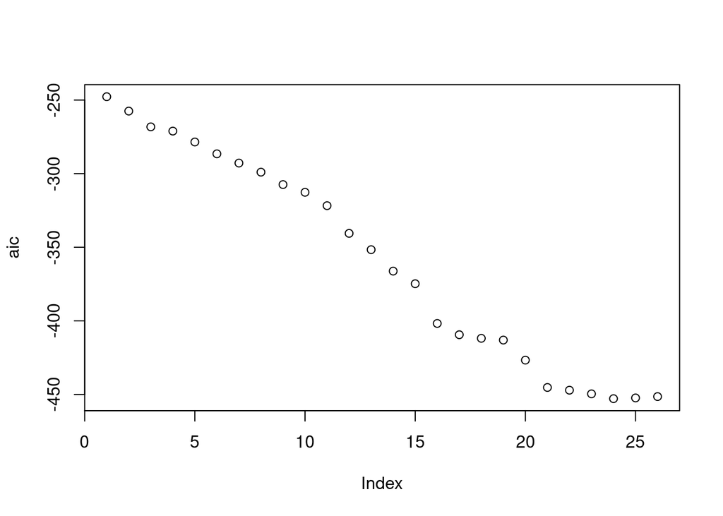

```r
k <- c()
for (i in 1:length(bic)){
  k[i] <- length(coef(r.bwd, i))-1
}
aic = bic - log(nrow(automobile))*k + 2*k
plot(aic)
```

```r
automobile.matrix = model.matrix(price ~ . - num.of.cylinders -engine.type -fuel.system -symboling -normalized.losses -fuel.type -drive.wheels -stroke -compression.ratio -horsepower -peak.rpm -city.mpg -highway.mpg -num.of.doors -width -engine.size -bore, data=automobile)

bwj.matrix = automobile.matrix[,names(beta)]
(yhat = drop(bwj.matrix %*% beta))
```

```
##         1         2         3         4         5         6         7         8
## 15617.242 19531.051 18801.755 22176.712 16648.329 16648.329 19286.665 19747.327
##         9        10        11        12        13        14        15        16
##  3067.252  7176.311  7777.437  5515.476  5515.476  9103.741  6407.214  7373.581
##        17        18        19        20        21        22        23        24
##  7373.581  7510.187 13521.744  5610.949  6498.770  7531.975  8394.669  8528.680
##        25        26        27        28        29        30        31        32
##  7497.529  6571.184  8715.326  9159.237  8257.183  8826.728  9605.665 11203.105
##        33        34        35        36        37        38        39        40
## 32759.790  6631.154  6714.911  6756.790  6615.034  6656.912 10332.195 10157.719
##        41        42        43        44        45        46        47        48
## 10332.195 10157.719  9501.252 16024.118 27409.490 28340.589 26295.036 30073.973
##        49        50        51        52        53        54        55        56
## 32761.515  5367.844  5585.611  6088.152  8457.719 10044.713  8215.339  7980.362
##        57        58        59        60        61        62        63        64
##  8315.389  9776.234  8298.637  6132.427  7204.512  6375.321  6542.835  7497.685
##        65        66        67        68        69        70        71        72
##  6651.718  7242.808  6819.232  7606.569  7451.473  8654.614  9252.452 15599.408
##        73        74        75        76        77        78        79        80
## 16548.922 14832.134 16155.628 18202.770 18711.491 13813.349 16773.439 14274.011
##        81        82        83        84        85        86        87        88
## 17234.101 14274.011 17234.101 16706.987  6064.169  9300.656  6604.129  5806.029
##        89        90        91        92        93        94        95        96
##  7497.914  7707.103 20255.385 14433.848 15525.849 14844.255 16053.517 17167.794
##        97        98        99       100       101       102       103       104
## 18276.548  6314.747  6737.553  6380.064  7646.121  8023.026  9279.376  8407.741
##       105       106       107       108       109       110       111       112
## 10932.296  8596.794  9978.780  8397.251 11801.251  6151.462  6612.124  6402.732
##       113       114       115       116       117       118       119       120
##  5014.171  5097.927 11965.976  7466.734  7048.703  9091.614  8439.064  7575.618
##       121       122       123       124       125       126       127       128
##  7157.587  8090.451  7575.092  7086.139  8379.157  7890.203 10278.259 10244.756
##       129       130       131       132       133       134       135       136
## 10765.099 11442.477 12130.332 19963.485  9533.682 12301.131 10136.399 10270.741
##       137       138       139       140       141       142       143       144
## 10504.929 14989.115 15324.142 15666.702  8353.165  7917.630  8378.292  7942.757
##       145       146       147       148       149       150       151       152
##  8470.424 10316.550  8679.816  9846.364 15353.967 15921.600 15546.608 15988.606
##       153       154       155       156       157       158       159
## 17945.528 18429.404 18124.128 20414.165 18626.668 21821.277 20523.048
```

```r
resid = automobile$price - yhat
(mse = mean(resid^2))
```

```
## [1] 1552170
```

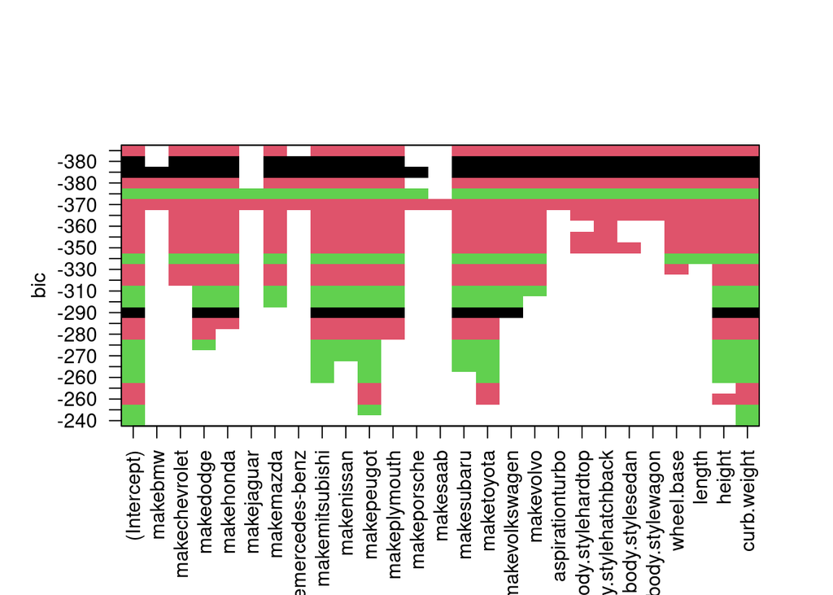

```r
plot(r.bwd, col=factor(automobile$drive.wheels))
```

# Lasso

## 10. Compute the Lasso model.

```r
x = automobile.matrix[,-1]     # remove the intercept term
y = automobile$price
(r.lasso = glmnet(x, y, alpha=1))
```

```
##
## Call:  glmnet(x = x, y = y, alpha = 1)
##
##    Df  %Dev Lambda
## 1   0  0.00 5236.0
## 2   1 13.56 4771.0
## 3   1 24.82 4347.0
## 4   1 34.16 3961.0
## 5   1 41.92 3609.0
## 6   1 48.36 3288.0
## 7   1 53.71 2996.0
## 8   1 58.15 2730.0
## 9   1 61.83 2488.0
## 10  1 64.89 2267.0
## 11  1 67.44 2065.0
```

[output cut: 79 more lines]

```r
names(r.lasso)
```

```
##  [1] "a0"        "beta"      "df"        "dim"       "lambda"    "dev.ratio"
##  [7] "nulldev"   "npasses"   "jerr"      "offset"    "call"      "nobs"
```

```r
coef(r.lasso)[,10]
```

```
##         (Intercept)             makebmw       makechevrolet           makedodge
##        -3766.780954            0.000000            0.000000            0.000000
##           makehonda          makejaguar           makemazda   makemercedes-benz
##            0.000000            0.000000            0.000000            0.000000
##      makemitsubishi          makenissan          makepeugot        makeplymouth
##            0.000000            0.000000            0.000000            0.000000
##         makeporsche            makesaab          makesubaru          maketoyota
##            0.000000            0.000000            0.000000            0.000000
##      makevolkswagen           makevolvo     aspirationturbo   body.stylehardtop
##            0.000000            0.000000            0.000000            0.000000
## body.stylehatchback     body.stylesedan     body.stylewagon          wheel.base
##            0.000000            0.000000            0.000000            0.000000
##              length              height         curb.weight
##            0.000000            0.000000            6.181087
```

## 12. Choose 5 different λ-values within a seemingly reasonable range

```r
# lambda = 2
r.lasso1 = glmnet(x, y, alpha=1, lambda = 2)
(yhat1 = drop(predict(r.lasso, s=2, alpha=1, newx=x)))
```

```
##         1         2         3         4         5         6         7         8
## 14530.319 18136.162 17998.984 21245.154 17540.574 17540.574 19946.209 20366.241
##         9        10        11        12        13        14        15        16
##  3173.432  7204.198  7693.690  5634.015  5634.015  9060.134  6432.556  7071.046
##        17        18        19        20        21        22        23        24
##  7071.046  7658.361 13849.043  5506.431  6315.946  7070.753  7857.357  7979.548
##        25        26        27        28        29        30        31        32
##  7524.606  6145.925  9050.540  9455.297  8949.663  9468.975 10179.210 11010.508
##        33        34        35        36        37        38        39        40
## 32229.490  6563.294  6639.663  6677.848  6794.579  6832.763 10564.930 10294.113
##        41        42        43        44        45        46        47        48
## 10564.930 10294.113  9938.189 14817.633 28366.105 28964.459 27184.046 31002.255
##        49        50        51        52        53        54        55        56
## 33076.422  5197.885  5396.445  5854.661  8234.727 10269.059  8446.697  8111.732
##        57        58        59        60        61        62        63        64
##  8417.209  9903.547  8401.936  6333.554  7311.081  6555.025  6707.764  7405.984
##        65        66        67        68        69        70        71        72
##  6807.044  7520.405  6959.782  7505.264  7068.176  9153.173  9455.638 15500.736
##        73        74        75        76        77        78        79        80
## 16212.634 14985.164 16006.776 18027.699 18096.865 13917.062 16770.411 14337.094
##        81        82        83        84        85        86        87        88
## 17190.443 14337.094 17190.443 16649.602  5984.467  9089.835  6462.257  6141.033
##        89        90        91        92        93        94        95        96
##  7683.694  7688.062 21994.962 13830.587 14583.631 14204.797 15064.758 16477.739
##        97        98        99       100       101       102       103       104
## 17246.057  6279.832  6728.804  6547.462  7796.302  8139.964  9285.504  8640.276
##       105       106       107       108       109       110       111       112
## 11096.504  8402.667  9662.761  8374.563 11632.670  6110.364  6530.396  6339.472
##       113       114       115       116       117       118       119       120
##  5452.707  5529.076 11791.364  7440.173  7287.110  8921.739  8554.841  7539.453
##       121       122       123       124       125       126       127       128
##  7386.390  7994.332  7773.876  7570.691  8507.022  8303.837 10166.982 10136.434
##       129       130       131       132       133       134       135       136
## 10994.459 11228.516 12239.280 19036.277  9429.537 12107.236 10149.009 10101.588
##       137       138       139       140       141       142       143       144
## 10485.034 14890.309 15195.787 15542.166  8400.702  8003.581  8423.612  8026.492
##       145       146       147       148       149       150       151       152
##  8507.619 10345.255  8698.542  9571.978 15842.411 16043.900 16018.060 16104.996
##       153       154       155       156       157       158       159
## 18359.734 18484.854 17870.557 20112.951 18328.773 21395.956 20212.231
```

```r
resid1 = automobile$price - yhat1

# lambda = 4
r.lasso2 = glmnet(x, y, alpha=1, lambda = 4)
(yhat2 = drop(predict(r.lasso, s=4, alpha=1, newx=x)))
```

```
##         1         2         3         4         5         6         7         8
## 14301.177 17914.386 17809.988 21037.976 17527.100 17527.100 19934.433 20354.761
##         9        10        11        12        13        14        15        16
##  3178.616  7218.809  7716.886  5639.773  5639.773  9046.146  6437.187  7066.688
##        17        18        19        20        21        22        23        24
##  7066.688  7679.287 13903.793  5492.793  6302.880  7020.807  7807.967  7930.244
##        25        26        27        28        29        30        31        32
##  7529.564  6100.913  9080.865  9485.908  9025.407  9545.085 10255.822 11023.084
##        33        34        35        36        37        38        39        40
## 32204.252  6545.273  6621.696  6659.908  6814.227  6852.439 10591.677 10326.449
##        41        42        43        44        45        46        47        48
## 10591.677 10326.449  9979.714 14753.285 28405.955 28980.617 27223.914 31046.127
##        49        50        51        52        53        54        55        56
## 32880.949  5175.819  5374.520  5833.059  8201.075 10280.961  8479.477  8149.780
##        57        58        59        60        61        62        63        64
##  8455.473  9920.695  8440.189  6329.625  7307.843  6551.252  6704.099  7381.514
##        65        66        67        68        69        70        71        72
##  6803.449  7518.436  6956.296  7480.865  7025.053  9179.215  9472.453 15537.245
##        73        74        75        76        77        78        79        80
## 16233.065 15038.990 16050.013 18050.198 18093.937 13938.674 16771.873 14359.002
##        81        82        83        84        85        86        87        88
## 17192.201 14359.002 17192.201 16643.854  5978.215  9063.610  6454.650  6186.419
##        89        90        91        92        93        94        95        96
##  7730.169  7696.751 21969.893 13851.917 14596.053 14226.391 15077.520 16478.773
##        97        98        99       100       101       102       103       104
## 17238.193  6266.725  6722.111  6558.715  7814.565  8158.470  9304.819  8676.766
##       105       106       107       108       109       110       111       112
## 11112.563  8394.425  9655.409  8384.182 11622.424  6087.935  6508.263  6317.205
##       113       114       115       116       117       118       119       120
##  5483.618  5560.041 11826.750  7442.895  7297.473  8925.507  8566.099  7542.246
##       121       122       123       124       125       126       127       128
##  7396.823  7995.755  7802.544  7608.656  8536.208  8342.319 10186.342 10155.773
##       129       130       131       132       133       134       135       136
## 11028.498 11248.626 12274.198 18765.548  9425.694 12083.119 10146.658 10098.219
##       137       138       139       140       141       142       143       144
## 10482.921 14917.380 15223.073 15584.951  8415.615  8018.214  8438.542  8041.141
##       145       146       147       148       149       150       151       152
##  8522.607 10339.376  8713.666  9557.958 15895.863 16065.770 16071.636 16126.908
##       153       154       155       156       157       158       159
## 18392.799 18486.282 17861.681 20083.493 18320.220 21367.404 20182.843
```

```r
resid2 = automobile$price - yhat2

# lambda = 6
r.lasso3 = glmnet(x, y, alpha=1, lambda = 6)
(yhat3 = drop(predict(r.lasso, s=6, alpha=1, newx=x)))
```

```
##         1         2         3         4         5         6         7         8
## 14074.059 17694.540 17622.692 20832.608 17513.589 17513.589 19922.561 20343.175
##         9        10        11        12        13        14        15        16
##  3183.870  7233.319  7740.017  5645.462  5645.462  9032.205  6441.740  7062.321
##        17        18        19        20        21        22        23        24
##  7062.321  7699.896 13958.312  5479.379  6290.017  6970.941  7758.636  7880.997
##        25        26        27        28        29        30        31        32
##  7534.416  6056.065  9110.975  9516.294  9100.872  9620.904 10332.124 11035.589
##        33        34        35        36        37        38        39        40
## 32178.806  6527.361  6603.836  6642.074  6833.961  6872.199 10618.262 10358.613
##        41        42        43        44        45        46        47        48
## 10618.262 10358.613 10020.991 14688.810 28445.052 28996.248 27263.189 31089.090
##        49        50        51        52        53        54        55        56
## 32687.483  5153.716  5352.552  5811.404  8167.506 10292.796  8512.034  8187.582
##        57        58        59        60        61        62        63        64
##  8493.484  9937.754  8478.189  6325.693  7304.577  6547.471  6700.422  7357.371
##        65        66        67        68        69        70        71        72
##  6799.840  7516.413  6952.790  7456.789  6982.048  9205.005  9489.095 15573.327
##        73        74        75        76        77        78        79        80
## 16253.321 15092.363 16093.089 18072.686 18090.768 13960.175 16773.353 14380.789
##        81        82        83        84        85        86        87        88
## 17193.967 14380.789 17193.967 16638.168  5971.950  9037.497  6447.031  6231.741
##        89        90        91        92        93        94        95        96
##  7776.542  7705.188 21944.648 13873.100 14608.394 14247.829 15090.188 16479.795
##        97        98        99       100       101       102       103       104
## 17230.384  6253.558  6715.333  6569.777  7832.717  8176.856  9323.985  8713.019
##       105       106       107       108       109       110       111       112
## 11128.525  8386.370  9648.212  8393.879 11612.376  6065.507  6486.121  6294.933
##       113       114       115       116       117       118       119       120
##  5514.589  5591.065 11862.039  7445.654  7307.802  8929.275  8577.292  7545.072
##       121       122       123       124       125       126       127       128
##  7407.220  7997.211  7831.219  7646.547  8565.382  8380.710 10205.648 10175.058
##       129       130       131       132       133       134       135       136
## 11062.351 11268.655 12308.898 18497.206  9421.672 12058.957 10144.081 10094.654
##       137       138       139       140       141       142       143       144
## 10480.572 14944.113 15250.015 15627.306  8430.518  8032.847  8453.461  8055.789
##       145       146       147       148       149       150       151       152
##  8537.584 10333.640  8728.772  9544.109 15949.169 16087.780 16125.062 16148.960
##       153       154       155       156       157       158       159
## 18425.856 18487.992 17852.694 20054.070 18311.546 21338.855 20153.488
```

```r
resid3 = automobile$price - yhat3

# lambda = 8
r.lasso4 = glmnet(x, y, alpha=1, lambda = 8)
(yhat4 = drop(predict(r.lasso, s=8, alpha=1, newx=x)))
```

```
##         1         2         3         4         5         6         7         8
## 13845.214 17473.190 17433.879 20625.662 17500.127 17500.127 19910.850 20331.770
##         9        10        11        12        13        14        15        16
##  3189.287  7247.840  7763.194  5651.201  5651.201  9018.238  6446.355  7057.932
##        17        18        19        20        21        22        23        24
##  7057.932  7720.523 14013.348  5466.055  6277.282  6920.714  7708.981  7831.431
##        25        26        27        28        29        30        31        32
##  7539.244  6010.777  9141.279  9546.893  9176.855  9697.265 10409.002 11048.058
##        33        34        35        36        37        38        39        40
## 32153.541  6509.393  6585.924  6624.190  6853.871  6892.137 10644.961 10390.983
##        41        42        43        44        45        46        47        48
## 10644.961 10390.983 10062.570 14623.657 28484.782 29012.269 27303.142 31132.525
##        49        50        51        52        53        54        55        56
## 32492.420  5131.488  5330.468  5789.653  8133.813 10304.664  8544.775  8225.678
##        57        58        59        60        61        62        63        64
##  8531.802  9954.956  8516.496  6321.708  7301.303  6543.648  6696.710  7332.780
##        65        66        67        68        69        70        71        72
##  6796.200  7514.375  6949.261  7432.270  6938.659  9230.995  9505.835 15609.761
##        73        74        75        76        77        78        79        80
## 16273.673 15146.190 16136.771 18095.641 18087.556 13981.818 16774.874 14402.738
##        81        82        83        84        85        86        87        88
## 17195.794 14402.738 17195.794 16632.420  5965.630  9011.238  6439.355  6277.337
##        89        90        91        92        93        94        95        96
##  7823.260  7713.523 21919.464 13894.351 14620.724 14269.352 15102.868 16480.774
##        97        98        99       100       101       102       103       104
## 17222.453  6240.418  6708.647  6581.195  7850.884  8195.273  9343.236  8749.572
##       105       106       107       108       109       110       111       112
## 11144.668  8377.975  9640.735  8403.483 11602.153  6042.998  6463.918  6272.590
##       113       114       115       116       117       118       119       120
##  5545.836  5622.367 11897.898  7448.430  7318.231  8933.128  8588.643  7547.920
##       121       122       123       124       125       126       127       128
##  7417.721  7998.685  7860.148  7684.798  8594.844  8419.494 10225.027 10194.415
##       129       130       131       132       133       134       135       136
## 11096.440 11288.806 12343.893 18226.107  9417.473 12034.509 10141.355 10090.945
##       137       138       139       140       141       142       143       144
## 10478.091 14970.965 15277.088 15669.916  8445.477  8047.516  8468.436  8070.475
##       145       146       147       148       149       150       151       152
##  8552.620 10327.816  8743.947  9530.087 16002.921 16109.866 16178.942 16171.091
##       153       154       155       156       157       158       159
## 18459.242 18489.656 17843.504 20024.314 18302.690 21310.032 20123.804
```

```r
resid4 = automobile$price - yhat4

# lambda = 10
r.lasso5 = glmnet(x, y, alpha=1, lambda = 10)
(yhat5 = drop(predict(r.lasso, s=10, alpha=1, newx=x)))
```

```
##         1         2         3         4         5         6         7         8
## 13618.719 17254.389 17247.194 20420.808 17486.556 17486.556 19899.114 20320.354
##         9        10        11        12        13        14        15        16
##  3195.043  7262.194  7786.108  5656.969  5656.969  9004.252  6451.010  7053.385
##        17        18        19        20        21        22        23        24
##  7053.385  7740.604 14068.672  5453.240  6265.085  6870.156  7659.024  7781.567
##        25        26        27        28        29        30        31        32
##  7543.709  5965.006  9171.534  9577.456  9252.929  9773.735 10486.014 11060.173
##        33        34        35        36        37        38        39        40
## 32128.209  6491.537  6568.126  6606.421  6873.965  6912.260 10671.552 10423.181
##        41        42        43        44        45        46        47        48
## 10671.552 10423.181 10104.186 14557.206 28524.527 29028.338 27343.521 31175.486
##        49        50        51        52        53        54        55        56
## 32296.825  5109.162  5308.293  5767.828  8100.084 10316.430  8577.519  8263.728
##        57        58        59        60        61        62        63        64
##  8570.084  9972.003  8554.766  6317.552  7297.893  6539.660  6692.839  7307.953
##        65        66        67        68        69        70        71        72
##  6792.405  7512.327  6945.583  7407.518  6894.939  9256.969  9522.351 15645.957
##        73        74        75        76        77        78        79        80
## 16293.821 15199.869 16181.167 18119.209 18084.017 14003.436 16776.301 14424.677
##        81        82        83        84        85        86        87        88
## 17197.541 14424.677 17197.541 16626.490  5959.303  8984.912  6431.671  6323.081
##        89        90        91        92        93        94        95        96
##  7870.181  7721.264 21894.208 13915.570 14632.829 14290.857 15115.340 16481.644
##        97        98        99       100       101       102       103       104
## 17214.220  6227.387  6702.123  6593.001  7868.817  8213.468  9362.305  8786.123
##       105       106       107       108       109       110       111       112
## 11160.724  8369.315  9633.036  8413.017 11591.804  6020.544  6441.784  6250.311
##       113       114       115       116       117       118       119       120
##  5577.533  5654.122 11934.431  7451.229  7328.879  8937.058  8600.259  7550.794
##       121       122       123       124       125       126       127       128
##  7428.445  8000.185  7889.377  7723.560  8624.633  8458.815 10244.457 10213.821
##       129       130       131       132       133       134       135       136
## 11130.690 11309.046 12379.093 17952.980  9412.697 12009.406 10138.204 10086.681
##       137       138       139       140       141       142       143       144
## 10475.196 14997.584 15303.941 15712.167  8460.427  8062.164  8483.404  8085.141
##       145       146       147       148       149       150       151       152
##  8567.652 10321.881  8759.125  9516.198 16057.079 16132.294 16233.234 16193.565
##       153       154       155       156       157       158       159
## 18492.951 18491.577 17833.874 19994.025 18293.409 21280.723 20093.591
```

```r
resid5 = automobile$price - yhat5
```

### Compute the MSEs of the corresponding 5 Lasso subset models

```r
# MSE for lambda = 2
(mse1 = mean(resid1^2))
```

```
## [1] 1405995
```

```r
# MSE for lambda = 4
(mse2 = mean(resid2^2))
```

```
## [1] 1414962
```

```r
# MSE for lambda = 6
(mse3 = mean(resid3^2))
```

```
## [1] 1428879
```

```r
# MSE for lambda = 8
(mse4 = mean(resid4^2))
```

```
## [1] 1447973
```

```r
# MSE for lambda = 10
(mse5 = mean(resid5^2))
```

```
## [1] 1472097
```

### Write R code to find out how many variables are included in each Lasso subset model

```r
# number of variables in lambda = 2
paste(r.lasso1$df-1)
```

```
## [1] "25"
```

```r
# number of variables in lambda = 4
paste(r.lasso2$df-1)
```

```
## [1] "25"
```

```r
# number of variables in lambda = 6
paste(r.lasso3$df-1)
```

```
## [1] "25"
```

```r
# number of variables in lambda = 8
paste(r.lasso4$df-1)
```

```
## [1] "25"
```

```r
# number of variables in lambda = 10
paste(r.lasso5$df-1)
```

```
## [1] "25"
```

The mse gradually rises as the lambda increases. At higher lambdas such as 30+, the number of variables begins to decrease from 25 to 24, 23, etc.

# Summary

In this lab we explored different methods of linear regression. We first cleaned the data by removing the missing values represetned by “?”. We then practices basic queries in R to find stuff like the mean, counts and different types of variables in the data. We then used pairwise scatter plots to show some visualization.